# Gaussian process regression in R using GPflow

Paul D W Kirk

2025-11-19

```r
library(reticulate)
library(ggplot2)
library(dplyr)
library(tidyr)
library(purrr)

#Note: several examples taken or adapted from the gplite vignette.  Credit to Juho Piironen.


# Point reticulate at the conda environment with GPflow installed
use_condaenv("r-gpflow", required = TRUE)

# Import Python modules
gpf <- import("gpflow")
tf  <- import("tensorflow")
np  <- import("numpy", convert = FALSE)

gpf$config$set_default_float(tf$float64)

# Check versions (mirroring the GPflow kernels notebook)
py_run_string("
import sys, gpflow, tensorflow as tf, check_shapes
print('Python      :', sys.version.replace('\\n', ' '))
print('GPflow      :', gpflow.__version__)
print('TensorFlow  :', tf.__version__)
print('check_shapes:', getattr(check_shapes, '__version__', 'unknown'))
")
```

```
## Python      : 3.10.19 | packaged by conda-forge | (main, Oct 22 2025, 22:48:40) [Clang 19.1.7 ]
## GPflow      : 2.9.2
## TensorFlow  : 2.16.2
## check_shapes: 1.1.1
```

# Introduction

This document shows how to use **GPflow** (a Gaussian process library written in Python and built on TensorFlow) from **R** via **reticulate**.

The structure roughly mirrors the official GPflow “getting started with kernels” notebook, but everything is driven from R:

- construct synthetic data;
- fit Gaussian process (GP) regression models with different covariance functions (kernels);
- visualise posterior mean and uncertainty;
- explore GP *priors* by drawing sample paths for different kernel hyperparameters;
- demonstrate composite kernels formed by sums and products.

All the statistical computation is done in Python/GPflow; R is used for orchestration and plotting.

# Synthetic data

We start with a simple one-dimensional regression problem: noisy observations of a sine function.

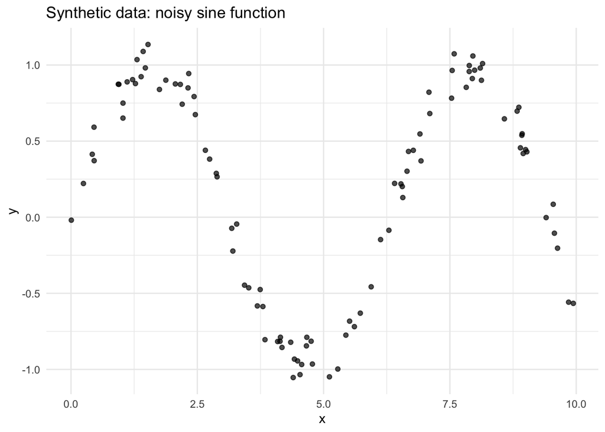

```r
set.seed(123)

N <- 100L
X <- matrix(runif(N, 0, 10), ncol = 1)
Y <- matrix(sin(X) + rnorm(N, 0, 0.1), ncol = 1)

df_data <- data.frame(
  x = as.numeric(X),
  y = as.numeric(Y)
)

ggplot(df_data, aes(x = x, y = y)) +
  geom_point(alpha = 0.7) +
  labs(
    x = "x",
    y = "y",
    title = "Synthetic data: noisy sine function"
  ) +
  theme_minimal()
```

# Converting data to NumPy and building a GP model

GPflow expects NumPy arrays (or TensorFlow tensors). We use `numpy$array` to convert R matrices into NumPy arrays.

```r
# Convert R matrices to NumPy arrays
X_np <- np$array(X)
Y_np <- np$array(Y)
```

We now define a helper that:

1. Builds a GP regression model with a supplied kernel;
2. Optimises the marginal log-likelihood using GPflow’s Scipy optimiser;
3. Returns the fitted model.

This is analogous to what the GPflow notebooks do with helper functions like `plot_kernel_prediction`.

```r
fit_gpr_model <- function(X_np, Y_np, kernel) {
  model <- gpf$models$GPR(
    data   = reticulate::tuple(X_np, Y_np),
    kernel = kernel
  )

  scipy_opt <- gpf$optimizers$Scipy()
  scipy_opt$minimize(
    model$training_loss,
    variables = model$trainable_variables
  )

  model
}
```

# Predictive mean and uncertainty for a single kernel

First, we reproduce a standard squared exponential (RBF) example.

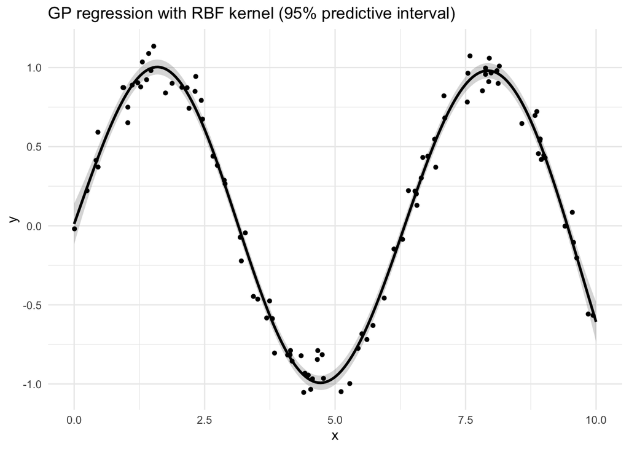

```r
# Prediction grid in R, then converted to NumPy
Xnew_R  <- matrix(seq(0, 10, length.out = 200), ncol = 1)
Xnew_np <- np$array(Xnew_R)

# RBF (squared exponential) kernel
kernel_rbf <- gpf$kernels$SquaredExponential()

# Fit model
model_rbf <- fit_gpr_model(X_np, Y_np, kernel_rbf)

# Predictive mean and variance
pred_rbf  <- model_rbf$predict_f(Xnew_np)
Ymean_rbf <- pred_rbf[[1]]$numpy()
Yvar_rbf  <- pred_rbf[[2]]$numpy()

mean_vec  <- as.numeric(Ymean_rbf)
var_vec   <- as.numeric(Yvar_rbf)
sd_vec    <- sqrt(var_vec)

df_pred_rbf <- data.frame(
  x     = as.numeric(Xnew_R[, 1]),
  mean  = mean_vec,
  lower = mean_vec - 1.96 * sd_vec,
  upper = mean_vec + 1.96 * sd_vec
)

ggplot() +
  geom_ribbon(
    data = df_pred_rbf,
    aes(x = x, ymin = lower, ymax = upper),
    alpha = 0.2
  ) +
  geom_line(
    data = df_pred_rbf,
    aes(x = x, y = mean),
    linewidth = 1
  ) +
  geom_point(
    data = df_data,
    aes(x = x, y = y),
    size = 1.2
  ) +
  labs(
    x = "x",
    y = "y",
    title = "GP regression with RBF kernel (95% predictive interval)"
  ) +
  theme_minimal()
```

# Visualising kernels via GP priors

In the GPflow kernels notebook, helper functions like `plot_kernel_samples` draw sample paths from the GP *prior* for a given kernel and set of hyperparameters. Here we implement a similar idea in R:

1. Fix a grid of inputs;
2. Compute the covariance matrix (K(x, x’)) implied by the kernel;
3. Draw sample paths from the multivariate normal ((0, K)).

For the prior visualisations below, we compute the squared exponential covariance directly in R (rather than via GPflow) and sample from the resulting multivariate normal. This is mathematically identical to what GPflow would do, but avoids some low-level numerical quirks when interacting with TensorFlow via reticulate. The posterior fitting and prediction continue to use GPflow as intended.

```r
# Input grid for prior visualisation (used for plotting)
Xgrid_R <- matrix(seq(0, 10, length.out = 100), ncol = 1)

# Squared Exponential / RBF covariance in pure R
rbf_covariance <- function(x, lengthscale, variance) {
  x <- as.numeric(x)
  dists <- as.matrix(dist(x))
  K <- variance * exp(- (dists^2) / (2 * lengthscale^2))
  K
}

# Helper to draw from a zero-mean GP prior with covariance K
draw_gp_prior_R <- function(K, n_draws = 5L, jitter = 1e-6) {
  n <- nrow(K)
  K_jitter <- K + diag(jitter, n)
  L <- chol(K_jitter)
  Z <- matrix(rnorm(n * n_draws), nrow = n)  # standard normals
  F <- t(L) %*% Z                            # each column is a GP draw
  F
}
```

## RBF prior with different lengthscales and variance

We define several RBF kernels with different hyperparameter settings. This closely parallels the prior plots in the GPflow documentation.

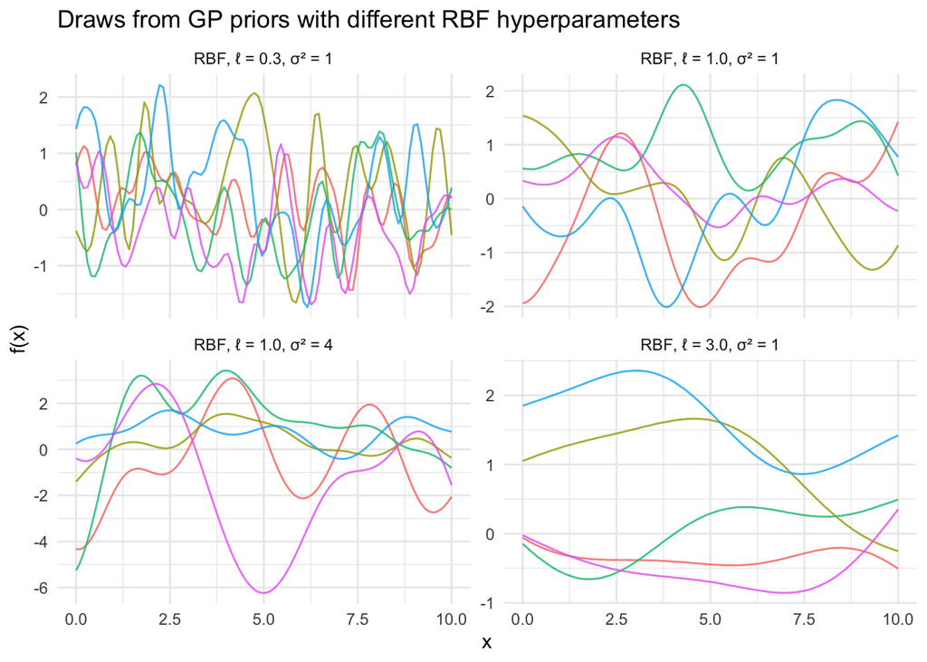

```r
# Define RBF hyperparameters (matching the GPflow examples)
rbf_params <- list(
  "RBF, ℓ = 0.3, σ² = 1"  = list(ell = 0.3, var = 1.0),
  "RBF, ℓ = 1.0, σ² = 1"  = list(ell = 1.0, var = 1.0),
  "RBF, ℓ = 3.0, σ² = 1"  = list(ell = 3.0, var = 1.0),
  "RBF, ℓ = 1.0, σ² = 4"  = list(ell = 1.0, var = 4.0)
)

n_draws <- 5L

prior_draws_list <- purrr::imap_dfr(
  rbf_params,
  function(pars, label) {
    K   <- rbf_covariance(Xgrid_R[, 1], lengthscale = pars$ell, variance = pars$var)
    F   <- draw_gp_prior_R(K, n_draws = n_draws)
    dfF <- as.data.frame(F)
    names(dfF) <- paste0("draw_", seq_len(n_draws))

    df_long <- dfF |>
      mutate(x = as.numeric(Xgrid_R[, 1])) |>
      tidyr::pivot_longer(
        cols = starts_with("draw_"),
        names_to = "draw",
        values_to = "f"
      ) |>
      mutate(kernel = label)

    df_long
  }
)

ggplot(prior_draws_list, aes(x = x, y = f, group = draw, colour = draw)) +
  geom_line(alpha = 0.8) +
  facet_wrap(~ kernel, ncol = 2, scales = "free_y") +
  labs(
    x = "x",
    y = "f(x)",
    title = "Draws from GP priors with different RBF hyperparameters"
  ) +
  theme_minimal() +
  theme(legend.position = "none")
```

You should see that:

- smaller lengthscales produce very wiggly functions;
- larger lengthscales produce smoother, slowly varying functions;
- larger variance increases the vertical spread of the prior.

# Comparing different covariance functions

GPflow provides a range of kernels. Here we compare:

- Squared Exponential (RBF);
- Matérn 3/2;
- Rational Quadratic.

We fit a model for each kernel and plot the predictive means together. This mirrors the spirit of GPflow’s `plot_kernel_prediction` helper, but implemented in R.

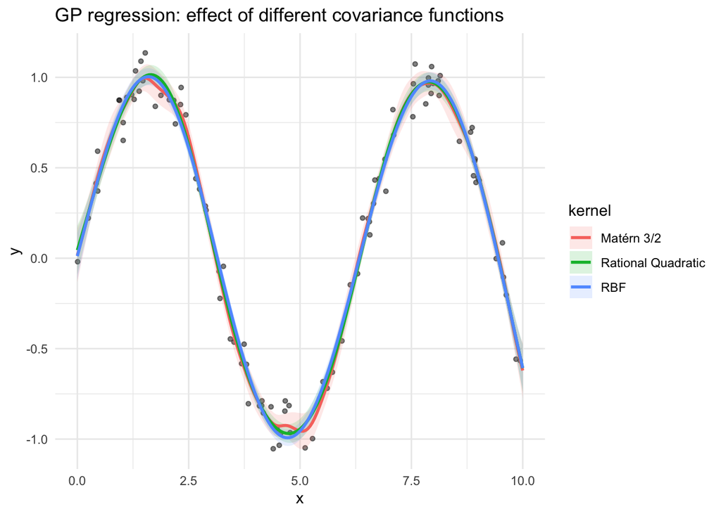

```r
# Define kernels
kernel_list <- list(
  "RBF"                = gpf$kernels$SquaredExponential(),
  "Matérn 3/2"         = gpf$kernels$Matern32(),
  "Rational Quadratic" = gpf$kernels$RationalQuadratic()
)

# Fit models for each kernel
models <- lapply(kernel_list, function(k) fit_gpr_model(X_np, Y_np, k))

# Function to get prediction data frame from a model
prediction_df <- function(model, Xnew_R, Xnew_np, name) {
  pred  <- model$predict_f(Xnew_np)
  mean  <- as.numeric(pred[[1]]$numpy())
  var   <- as.numeric(pred[[2]]$numpy())
  sd    <- sqrt(var)

  data.frame(
    x     = as.numeric(Xnew_R[, 1]),
    mean  = mean,
    lower = mean - 1.96 * sd,
    upper = mean + 1.96 * sd,
    kernel = name
  )
}

df_pred_all <- purrr::imap_dfr(models, ~prediction_df(.x, Xnew_R, Xnew_np, .y))

ggplot() +
  geom_point(
    data = df_data,
    aes(x = x, y = y),
    size = 1.2,
    alpha = 0.5
  ) +
  geom_ribbon(
    data = df_pred_all,
    aes(x = x, ymin = lower, ymax = upper, fill = kernel),
    alpha = 0.15
  ) +
  geom_line(
    data = df_pred_all,
    aes(x = x, y = mean, colour = kernel),
    linewidth = 1
  ) +
  labs(
    x = "x",
    y = "y",
    title = "GP regression: effect of different covariance functions"
  ) +
  theme_minimal()
```

# Composite kernels and structure

A key feature of GPflow (and GP modelling in general) is the ability to construct *composite* kernels by **summing** and **multiplying** simpler ones. This allows you to encode structure such as:

- long-term smooth trends plus short-term variation;
- periodic components plus noise;
- different behaviours in different input dimensions.

In GPflow, kernel objects support `+` and `*` operators. We demonstrate two simple composites:

- RBF + Linear: smooth function with a global linear trend;
- Periodic × RBF: locally smooth, periodic structure.

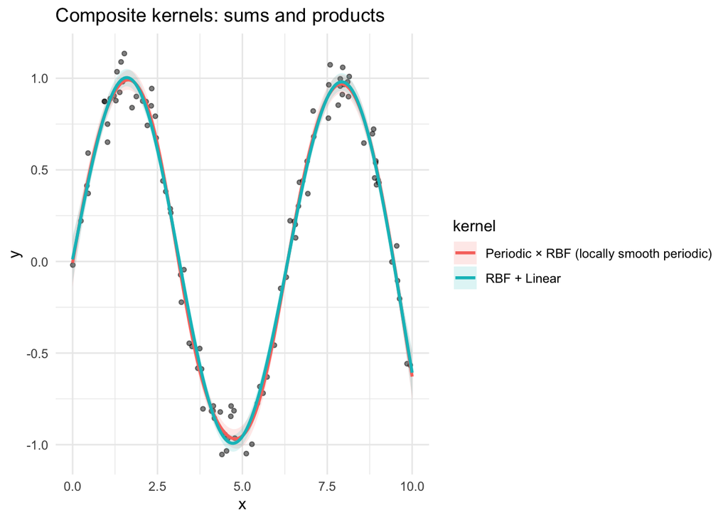

```r
# Base kernels
k_rbf      <- gpf$kernels$SquaredExponential()
k_linear   <- gpf$kernels$Linear()
k_per_base <- gpf$kernels$SquaredExponential(lengthscales = 0.5)
k_periodic <- gpf$kernels$Periodic(base_kernel = k_per_base, period = 2.0)

# Composite kernels
kernel_sum  <- k_rbf + k_linear                    # trend + smooth deviations
kernel_prod <- k_periodic * gpf$kernels$SquaredExponential(lengthscales = 2.0)

composite_kernels <- list(
  "RBF + Linear"                        = kernel_sum,
  "Periodic × RBF (locally smooth periodic)" = kernel_prod
)

# Fit models with composite kernels
models_composite <- lapply(composite_kernels, function(k) fit_gpr_model(X_np, Y_np, k))

df_pred_composite <- purrr::imap_dfr(
  models_composite,
  ~prediction_df(.x, Xnew_R, Xnew_np, .y)
)

ggplot() +
  geom_point(
    data = df_data,
    aes(x = x, y = y),
    size = 1.2,
    alpha = 0.5
  ) +
  geom_ribbon(
    data = df_pred_composite,
    aes(x = x, ymin = lower, ymax = upper, fill = kernel),
    alpha = 0.15
  ) +
  geom_line(
    data = df_pred_composite,
    aes(x = x, y = mean, colour = kernel),
    linewidth = 1
  ) +
  labs(
    x = "x",
    y = "y",
    title = "Composite kernels: sums and products"
  ) +
  theme_minimal()
```

You can experiment with different base kernels and hyperparameters to see how the composite behaviour changes.

# Additional worked examples (mirroring the gplite quickstart)

The following examples mirror those in a gplite-based quickstart document, but are implemented *only* using GPflow.

## Small-sample regression on ([0, 1])

This example uses only six design points on ([0,1]), showing how the GP interpolates and extrapolates with relatively little data.

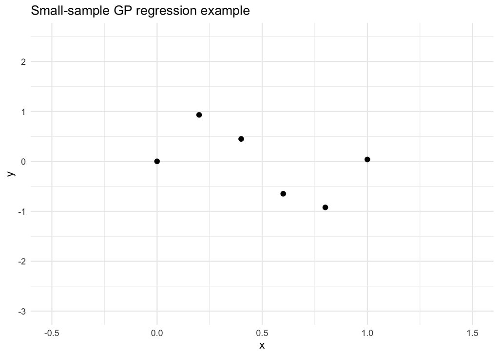

```r
set.seed(10)
n_small <- 6L
x_small <- matrix(seq(0, 1, length.out = n_small), ncol = 1)
y_small <- sin(2 * pi * x_small) + rnorm(n_small, 0, 1e-1)

df_small <- data.frame(
  x = as.numeric(x_small),
  y = as.numeric(y_small)
)

ggplot(df_small, aes(x = x, y = y)) +
  geom_point(size = 2) +
  xlab("x") + ylab("y") +
  xlim(-0.5, 1.5) + ylim(-3, 2.5) +
  ggtitle("Small-sample GP regression example") +
  theme_minimal()
```

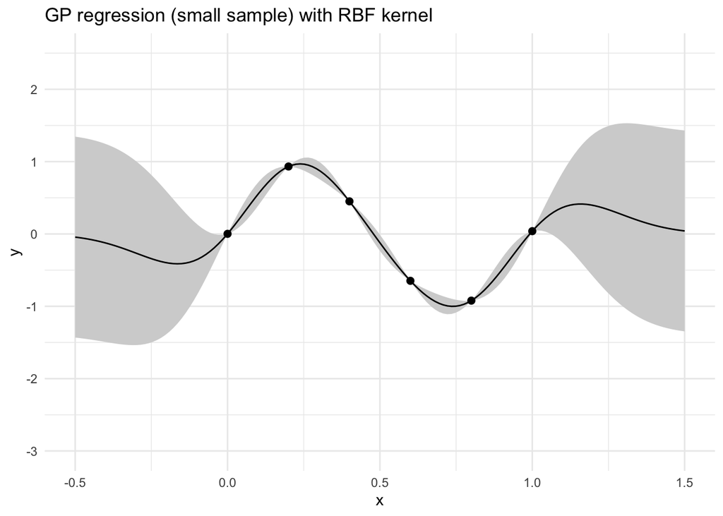

```r
# Convert to NumPy
X_small_np <- np$array(x_small)
Y_small_np <- np$array(y_small)

# Squared Exponential kernel
kernel_small <- gpf$kernels$SquaredExponential()

# Fit GP model
model_small <- fit_gpr_model(X_small_np, Y_small_np, kernel_small)

# Prediction grid
xt_small_R  <- matrix(seq(-0.5, 1.5, length.out = 150), ncol = 1)
xt_small_np <- np$array(xt_small_R)

pred_small  <- model_small$predict_f(xt_small_np)
Ymean_small <- pred_small[[1]]$numpy()
Yvar_small  <- pred_small[[2]]$numpy()

mean_small  <- as.numeric(Ymean_small)
var_small   <- as.numeric(Yvar_small)
sd_small    <- sqrt(var_small)

df_pred_small <- data.frame(
  x     = as.numeric(xt_small_R[, 1]),
  mean  = mean_small,
  lower = mean_small - 2 * sd_small,
  upper = mean_small + 2 * sd_small
)

ggplot() +
  geom_ribbon(
    data = df_pred_small,
    aes(x = x, ymin = lower, ymax = upper),
    fill = "lightgrey"
  ) +
  geom_line(
    data = df_pred_small,
    aes(x = x, y = mean),
    size = 0.5
  ) +
  geom_point(
    data = df_small,
    aes(x = x, y = y),
    size = 2
  ) +
  xlab("x") + ylab("y") +
  xlim(-0.5, 1.5) + ylim(-3, 2.5) +
  ggtitle("GP regression (small sample) with RBF kernel") +
  theme_minimal()
```

We can also draw sample functions from the **posterior** using `predict_f_samples`. This is analogous to `gp_draw` in gplite.

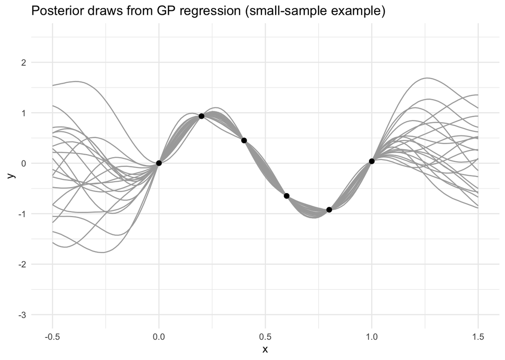

```r
ndraws <- 20L

# Predictive samples: shape [S, N, 1]
samples_tf <- model_small$predict_f_samples(xt_small_np, num_samples = as.integer(ndraws))
samples_arr <- samples_tf$numpy()  # R array with dims c(S, N, 1)

# Convert to matrix: N x S
samples_mat <- t(samples_arr[ , , 1])

df_draws_small <- as.data.frame(samples_mat)
names(df_draws_small) <- paste0("draw_", seq_len(ndraws))

df_draws_long <- df_draws_small |>
  mutate(x = as.numeric(xt_small_R[, 1])) |>
  pivot_longer(
    cols = starts_with("draw_"),
    names_to = "draw",
    values_to = "f"
  )

pp <- ggplot() + xlab("x") + ylab("y")

for (i in seq_len(ndraws)) {
  draw_name <- paste0("draw_", i)
  pp <- pp + geom_line(
    data = df_draws_long %>% filter(draw == draw_name),
    aes(x = x, y = f),
    colour = "darkgrey"
  )
}

pp +
  geom_point(data = df_small, aes(x = x, y = y), colour = "black", size = 2) +
  xlim(-0.5, 1.5) + ylim(-3, 2.5) +
  ggtitle("Posterior draws from GP regression (small-sample example)") +
  theme_minimal()
```

## Squared Exponential prior: alternative hyperparameter settings

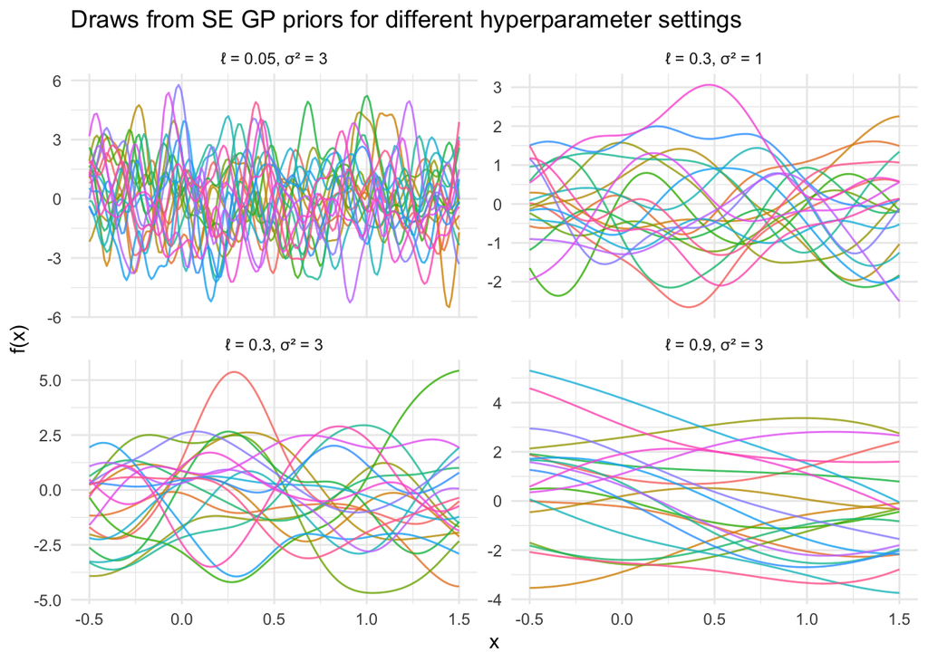

```r
set.seed(10)

# Match the four settings from the gplite example
rbf_params_alt <- list(
  "ℓ = 0.3, σ² = 1"  = list(ell = 0.3,  var = 1.0),
  "ℓ = 0.05, σ² = 3" = list(ell = 0.05, var = 3.0),
  "ℓ = 0.9, σ² = 3"  = list(ell = 0.9,  var = 3.0),
  "ℓ = 0.3, σ² = 3"  = list(ell = 0.3,  var = 3.0)
)

# Test points on [-0.5, 1.5]
Xgrid_se_R <- matrix(seq(-0.5, 1.5, length.out = 150), ncol = 1)

ndraws_se <- 20L

prior_draws_se <- purrr::imap_dfr(
  rbf_params_alt,
  function(pars, label) {
    K   <- rbf_covariance(Xgrid_se_R[, 1], lengthscale = pars$ell, variance = pars$var)
    F   <- draw_gp_prior_R(K, n_draws = ndraws_se)
    dfF <- as.data.frame(F)
    names(dfF) <- paste0("draw_", seq_len(ndraws_se))

    df_long <- dfF |>
      mutate(x = as.numeric(Xgrid_se_R[, 1])) |>
      tidyr::pivot_longer(
        cols = starts_with("draw_"),
        names_to = "draw",
        values_to = "f"
      ) |>
      mutate(setting = label)

    df_long
  }
)

ggplot(prior_draws_se, aes(x = x, y = f, group = draw, colour = draw)) +
  geom_line(alpha = 0.8) +
  facet_wrap(~ setting, ncol = 2, scales = "free_y") +
  labs(
    x = "x",
    y = "f(x)",
    title = "Draws from SE GP priors for different hyperparameter settings"
  ) +
  theme_minimal() +
  theme(legend.position = "none")
```

Again, shorter lengthscales correspond to more rapidly varying functions, and larger variances yield greater vertical spread.

## Quasi-periodic AirPassengers example

The gplite vignette uses the **AirPassengers** data to illustrate combining several covariance functions:

- a constant term;
- a linear trend;
- a quasi-periodic term (periodic with period 12, modulated by a long lengthscale SE).

We now construct an analogous composite kernel in GPflow.

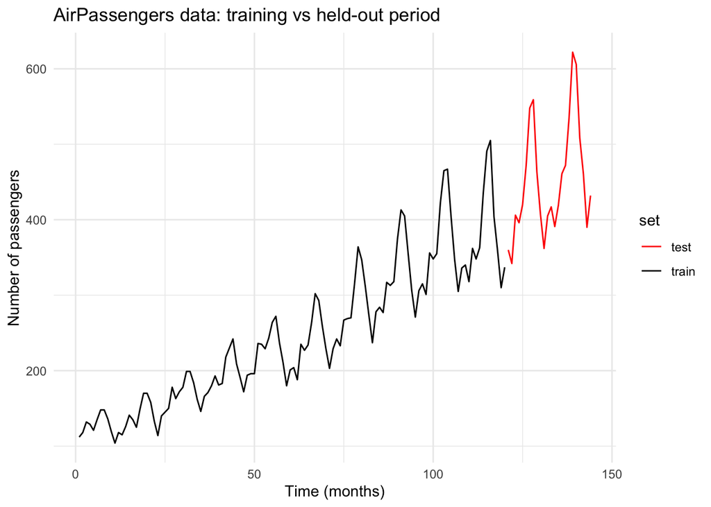

```r
y_all <- as.numeric(datasets::AirPassengers)
x_all <- seq_along(y_all)

# Hold out 2 years as a test set (though here we will actually predict for the full series)
nt    <- 24L
n_ap  <- length(x_all) - nt
x_tr  <- x_all[1:n_ap]
y_tr  <- y_all[1:n_ap]
xt_ap <- x_all
yt_ap <- y_all

df_ap <- data.frame(
  time = x_all,
  passengers = y_all,
  set = c(rep("train", n_ap), rep("test", nt))
)

ggplot() +
  geom_line(data = df_ap, aes(x = time, y = passengers, colour = set)) +
  scale_colour_manual(values = c("train" = "black", "test" = "red")) +
  xlab("Time (months)") + ylab("Number of passengers") +
  ggtitle("AirPassengers data: training vs held-out period") +
  theme_minimal()
```

We take logs to stabilise the variance and make the process closer to stationary.

```r
# Log transform
yscaled_tr <- log(y_tr)

# Convert to NumPy (ensure floating point, not integers)
X_ap_tr_R   <- matrix(as.numeric(x_tr),  ncol = 1)
X_ap_all_R  <- matrix(as.numeric(x_all), ncol = 1)

X_ap_tr_np  <- np$array(X_ap_tr_R)   # now float64
X_ap_all_np <- np$array(X_ap_all_R)
Y_ap_tr_np  <- np$array(matrix(as.numeric(yscaled_tr), ncol = 1))


# Construct composite kernel in GPflow to match gplite:
# Constant + Linear + (Periodic * SE_long) for quasi-periodic pattern

# Base kernels
k_const_ap   <- gpf$kernels$Constant()
k_linear_ap  <- gpf$kernels$Linear()

# Create periodic kernel with SHORT lengthscale base (for within-period correlation)
k_se_base <- gpf$kernels$SquaredExponential(lengthscales = 1.0)  # Short lengthscale for base
k_periodic_ap <- gpf$kernels$Periodic(base_kernel = k_se_base, period = 12.0)

# Create the modulation envelope (long lengthscale SE)
k_se_long_ap <- gpf$kernels$SquaredExponential(lengthscales = 100.0)

# MULTIPLY periodic and long SE to get quasi-periodic (matching gplite: cf2*cf3)
k_quasiperiodic <- k_periodic_ap * k_se_long_ap

# Final composite kernel (matching gplite: cf0 + cf1 + cf2*cf3)
kernel_ap <- k_const_ap + k_linear_ap + k_quasiperiodic

# Fit GP model on log data
model_ap <- fit_gpr_model(X_ap_tr_np, Y_ap_tr_np, kernel_ap)
```

We now predict on the full time range and transform back from log scale.

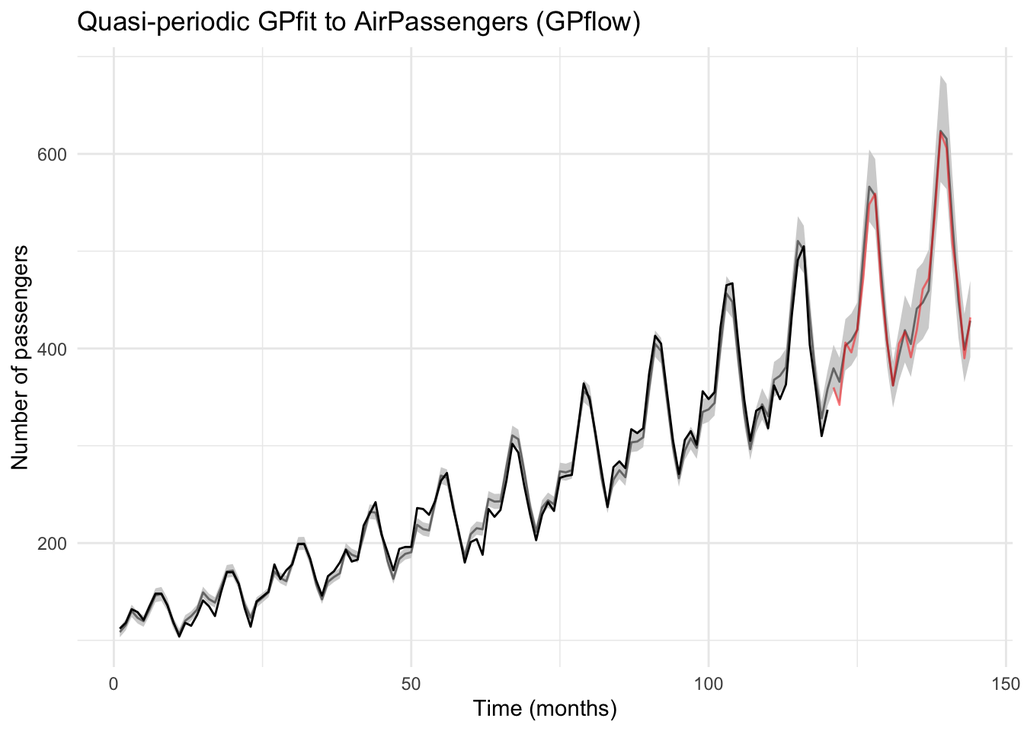

```r
pred_ap <- model_ap$predict_f(X_ap_all_np)

mean_ap_log <- as.numeric(pred_ap[[1]]$numpy())
var_ap_log  <- as.numeric(pred_ap[[2]]$numpy())
sd_ap_log   <- sqrt(var_ap_log)

# Back-transform to the original scale
pred_ap_mean <- exp(mean_ap_log)
pred_ap_lb   <- exp(mean_ap_log - 2 * sd_ap_log)
pred_ap_ub   <- exp(mean_ap_log + 2 * sd_ap_log)

df_pred_ap <- data.frame(
  time = x_all,
  mean = pred_ap_mean,
  lower = pred_ap_lb,
  upper = pred_ap_ub
)

ggplot() +
  geom_ribbon(
    data = df_pred_ap,
    aes(x = time, ymin = lower, ymax = upper),
    fill = "lightgrey"
  ) +
  geom_line(
    data = df_pred_ap,
    aes(x = time, y = mean),
    colour = "black",
    alpha = 0.5
  ) +
  geom_line(
    data = df_ap %>% filter(set == "train"),
    aes(x = time, y = passengers),
    colour = "black"
  ) +
  geom_line(
    data = df_ap %>% filter(set == "test"),
    aes(x = time, y = passengers),
    colour = "red",
    alpha = 0.5
  ) +
  xlab("Time (months)") +
  ylab("Number of passengers") +
  ggtitle("Quasi-periodic GPfit to AirPassengers (GPflow)") +
  theme_minimal()
```